# Tipologia i cicle de vida de les dades

Pràctica 2: Neteja i anàlisi de les dades

Autors: Adrià Tarradas i Aleix Arnau Soler

Desembre 2020

# 1 Presentació del projecte de ciència de dades

## 1.1 Background

L’enfonsament del Titanic és un dels naufragis més famosos de la història. El 15 d’abril de 1912, durant el seu viatge inaugural, el considerat “inenfonsable” RMS Titanic es va enfonsar després de xocar amb un iceberg. Malauradament, no hi havia prou bots salvavides per a tothom a bord, cosa que va provocar la mort de 1502 de 2224 passatgers i tripulants. Tot i que hi va haver algun element de sort per sobreviure, sembla ser que alguns grups de persones tenien més probabilitats de sobreviure que d’altres.

## 1.2 Objectiu

L’objectiu d’aquesta pràctica és la creació final d’un o varis models predictius que responguin a la pregunta: **“quin tipus de persones tenien més probabilitats de sobreviure?”**. Per això, caldrà primer netejar i analitzar les dades dels passatgers a bord del RMS Titanic (*i.e.* nom, edat, sexe, classe socioeconòmica, etc.) abans de construir els models per a predir quins passatgers van sobreviure a l’enfonsament del Titanic.

## 1.3 Descripció del dataset

El dataset que utilitzarem en aquesta pràctica és *Titanic: Machine Learning from Disaster*, disponible clicant a [*aquí*](https://www.kaggle.com/c/titanic).

Aquest conjunt de dades està compost per diversos atributs/característiques dels passatgers del titanic distribuïts en 2 fitxers: un dataset per entrenar els models i un altre per a testar-los. A més, s’incou un fitxer amb la predicció de la supervivencia dels passatgers (codificat com a 0: mort o 1: sobreviu) que assumeix que totes les dones, i només les dones, sobreviuen. Obviament, aquestes prediccions són irreals pero ens serveixen com a exemple de com hauria de ser el fitxer final amb les prediccions de supervivencia en cas de que es participés a una de les competició de [*Kaggle*](https://www.kaggle.com/). És per aquest motiu que les dades es proporcionen ja semparades en un dataset d’entrenament i un dataset de testeig, ja que així tots els membres que participen a la cometició de la web Kaggle parteixen de la mateixa informació i dades, i per tant es poden comparar entre ells els resultats obtinguts amb els diferents models implentats.

Els fitxers que componen el dataset són:

- **train.csv**: Conté totes les dades i variables d’un subgrup dels passatgers a bord del RMS Titanic (891 passatgers i tripulants), a més de la variable que ens indica si aquell passatger va morir o sobreviure. Aquest dataset serà el que s’utilitzarà per l’entrenament d’un model.
- **test.csv**: Conté totes les dades i variables d’un subgrup més petit que l’anterior dels passatgers a bord del RMS Titanic (en aquest cas 418 passatgers i tripulants) amb l’excepció de que aquest dataset no conté la variable que ens indica si el passatger va sobreviure o no. Aquestes dades s’utilitzaran per a poder testejar els models creats amb les dades del dataset d’entrenament.
- **gender_submission.csv**: Conté la classe dels passatgers (si sobreviuen o no) vinculada a l’identificador de cada passatger, assumint que totes les dones, i només les dones, haguessin sobreviscut.

Cada passatger conté informació de les següents variables:

Data diccionary: resum de les variables del dataset ‘Titanic: Machine Learning from Disaster’.

|  | Variables | Definició | Codificació |
| --- | --- | --- | --- |
|  | PassangerID | Número identificador del passatger |  |
|  | Survived | Enter que indica si el passatger va sobreviure l’enfonsament o no | 0 = No, 1 = Sí |
|  | Pclass | Enter que indica el tipus de tiquet del passatger | 1 = 1a classe, 2 = 2a classe, 3 = 3a classe |
|  | Name | Títol/Nom del passatger |  |
|  | Sex | Sexe del passatger |  |
|  | Age | Edat del passatger (anys) |  |
|  | SibSp | Número de cònjuges i germans del passatger a bord |  |
|  | Parch | Número de pares i fills del passatger a bord |  |
|  | Ticket | Número del tiquet del passatger |  |
|  | Fare | Preu pagat/Tarifa del viatge |  |
|  | Cabin | Número de cabina |  |
|  | Embarked | Port en el que ha embarcat el passatger | C = Cherbourg, Q = Queenstown, S = Southampton |

Notes a tenir en compte:

- La variable **pclass** ens serveix com a indicador indirecte del nivell socioeconomic del passatger (alt: 1a classe, mitjà: 2a classe, baix: 3a classe).
- L’edat dels menors d’1 any està codificada com la fracció d’any que tenen. Les edats és mostren com a fraccions on en alguns casos s’indica’ el ‘i mig’ (e.g. 35.50 = 35 anys i mig)
- Alguns nens viatjaven amb una mainadera, per tant és possible que per algun d’ells ‘parch’ sigui 0.

# 2 Integració i comprobació

Un cop les dades s’han descarregat des de l’enllaç proporcionat, carreguem les dades a l’entorn de treball.

```r
train_raw <- read.csv("data/train.csv", sep=',', stringsAsFactors = FALSE)
test_raw <- read.csv("data/test.csv", sep=',', stringsAsFactors = FALSE)
test_class_raw <- read.csv("data/gender_submission.csv", sep=',', stringsAsFactors = FALSE)
```

Primer inspeccionem els datasets:

```r
head(train_raw)
```

```
##   PassengerId Survived Pclass
## 1           1        0      3
## 2           2        1      1
## 3           3        1      3
## 4           4        1      1
## 5           5        0      3
## 6           6        0      3
##                                                  Name    Sex Age SibSp Parch
## 1                             Braund, Mr. Owen Harris   male  22     1     0
## 2 Cumings, Mrs. John Bradley (Florence Briggs Thayer) female  38     1     0
## 3                              Heikkinen, Miss. Laina female  26     0     0
## 4        Futrelle, Mrs. Jacques Heath (Lily May Peel) female  35     1     0
## 5                            Allen, Mr. William Henry   male  35     0     0
## 6                                    Moran, Mr. James   male  NA     0     0
##             Ticket    Fare Cabin Embarked
## 1        A/5 21171  7.2500              S
## 2         PC 17599 71.2833   C85        C
## 3 STON/O2. 3101282  7.9250              S
## 4           113803 53.1000  C123        S
## 5           373450  8.0500              S
## 6           330877  8.4583              Q
```

```r
head(test_raw)
```

```
##   PassengerId Pclass                                         Name    Sex  Age
## 1         892      3                             Kelly, Mr. James   male 34.5
## 2         893      3             Wilkes, Mrs. James (Ellen Needs) female 47.0
## 3         894      2                    Myles, Mr. Thomas Francis   male 62.0
## 4         895      3                             Wirz, Mr. Albert   male 27.0
## 5         896      3 Hirvonen, Mrs. Alexander (Helga E Lindqvist) female 22.0
## 6         897      3                   Svensson, Mr. Johan Cervin   male 14.0
##   SibSp Parch  Ticket    Fare Cabin Embarked
## 1     0     0  330911  7.8292              Q
## 2     1     0  363272  7.0000              S
## 3     0     0  240276  9.6875              Q
## 4     0     0  315154  8.6625              S
## 5     1     1 3101298 12.2875              S
## 6     0     0    7538  9.2250              S
```

```r
head(test_class_raw)
```

```
##   PassengerId Survived
## 1         892        0
## 2         893        1
## 3         894        0
## 4         895        0
## 5         896        1
## 6         897        0
```

Primer de tot extreurem la variable ‘Survived’ del dataset d’entrenament en un format igual al dataset ‘gender_submission.csv’ ja que aquesta no ens farà falta de moment i així podem integrar els dos datasets en un de sol per a dur a terme la neteja, inspecció i analisis en un sol dataset.

```r
train_predictions<-train_raw[,c("PassengerId","Survived")]
train_raw<-train_raw[,-2]
```

Comprovem que les dades s’han carregat correctamen i les inspeccionem. Dataset d’entrenament:

```r
# Comprovem que les dimensions del dataset siguin les esperades
dim(train_raw)
```

```
## [1] 891  11
```

```r
# Comprovem en quina classe es troben les variables
sapply(train_raw,class)
```

```
## PassengerId      Pclass        Name         Sex         Age       SibSp
##   "integer"   "integer" "character" "character"   "numeric"   "integer"
##       Parch      Ticket        Fare       Cabin    Embarked
##   "integer" "character"   "numeric" "character" "character"
```

```r
# Comprovem l'estructura
str(train_raw)
```

```
## 'data.frame':    891 obs. of  11 variables:
##  $ PassengerId: int  1 2 3 4 5 6 7 8 9 10 ...
##  $ Pclass     : int  3 1 3 1 3 3 1 3 3 2 ...
##  $ Name       : chr  "Braund, Mr. Owen Harris" "Cumings, Mrs. John Bradley (Florence Briggs Thayer)" "Heikkinen, Miss. Laina" "Futrelle, Mrs. Jacques Heath (Lily May Peel)" ...
##  $ Sex        : chr  "male" "female" "female" "female" ...
##  $ Age        : num  22 38 26 35 35 NA 54 2 27 14 ...
##  $ SibSp      : int  1 1 0 1 0 0 0 3 0 1 ...
##  $ Parch      : int  0 0 0 0 0 0 0 1 2 0 ...
##  $ Ticket     : chr  "A/5 21171" "PC 17599" "STON/O2. 3101282" "113803" ...
##  $ Fare       : num  7.25 71.28 7.92 53.1 8.05 ...
##  $ Cabin      : chr  "" "C85" "" "C123" ...
##  $ Embarked   : chr  "S" "C" "S" "S" ...
```

```r
# Inspeccionem alguns parametres bàsics
summary(train_raw)
```

```
##   PassengerId        Pclass          Name               Sex
##  Min.   :  1.0   Min.   :1.000   Length:891         Length:891
##  1st Qu.:223.5   1st Qu.:2.000   Class :character   Class :character
##  Median :446.0   Median :3.000   Mode  :character   Mode  :character
##  Mean   :446.0   Mean   :2.309
##  3rd Qu.:668.5   3rd Qu.:3.000
##  Max.   :891.0   Max.   :3.000
##
##       Age            SibSp           Parch           Ticket
##  Min.   : 0.42   Min.   :0.000   Min.   :0.0000   Length:891
##  1st Qu.:20.12   1st Qu.:0.000   1st Qu.:0.0000   Class :character
##  Median :28.00   Median :0.000   Median :0.0000   Mode  :character
##  Mean   :29.70   Mean   :0.523   Mean   :0.3816
##  3rd Qu.:38.00   3rd Qu.:1.000   3rd Qu.:0.0000
##  Max.   :80.00   Max.   :8.000   Max.   :6.0000
##  NA's   :177
##       Fare           Cabin             Embarked
##  Min.   :  0.00   Length:891         Length:891
##  1st Qu.:  7.91   Class :character   Class :character
##  Median : 14.45   Mode  :character   Mode  :character
##  Mean   : 32.20
##  3rd Qu.: 31.00
##  Max.   :512.33
##
```

```r
# Inspeccionem les dades
glimpse(train_raw)
```

```
## Rows: 891
## Columns: 11
## $ PassengerId <int> 1, 2, 3, 4, 5, 6, 7, 8, 9, 10, 11, 12, 13, 14, 15, 16, ...
## $ Pclass      <int> 3, 1, 3, 1, 3, 3, 1, 3, 3, 2, 3, 1, 3, 3, 3, 2, 3, 2, 3...
## $ Name        <chr> "Braund, Mr. Owen Harris", "Cumings, Mrs. John Bradley ...
## $ Sex         <chr> "male", "female", "female", "female", "male", "male", "...
## $ Age         <dbl> 22, 38, 26, 35, 35, NA, 54, 2, 27, 14, 4, 58, 20, 39, 1...
## $ SibSp       <int> 1, 1, 0, 1, 0, 0, 0, 3, 0, 1, 1, 0, 0, 1, 0, 0, 4, 0, 1...
## $ Parch       <int> 0, 0, 0, 0, 0, 0, 0, 1, 2, 0, 1, 0, 0, 5, 0, 0, 1, 0, 0...
## $ Ticket      <chr> "A/5 21171", "PC 17599", "STON/O2. 3101282", "113803", ...
## $ Fare        <dbl> 7.2500, 71.2833, 7.9250, 53.1000, 8.0500, 8.4583, 51.86...
## $ Cabin       <chr> "", "C85", "", "C123", "", "", "E46", "", "", "", "G6",...
## $ Embarked    <chr> "S", "C", "S", "S", "S", "Q", "S", "S", "S", "C", "S", ...
```

Dataset de testeig:

```r
# Comprovem que les dimensions del dataset siguin les esperades
dim(test_raw)
```

```
## [1] 418  11
```

```r
# Comprovem en quina classe es troben les variables
sapply(test_raw,class)
```

```
## PassengerId      Pclass        Name         Sex         Age       SibSp
##   "integer"   "integer" "character" "character"   "numeric"   "integer"
##       Parch      Ticket        Fare       Cabin    Embarked
##   "integer" "character"   "numeric" "character" "character"
```

```r
# Comprovem l'estructura
str(test_raw)
```

```
## 'data.frame':    418 obs. of  11 variables:
##  $ PassengerId: int  892 893 894 895 896 897 898 899 900 901 ...
##  $ Pclass     : int  3 3 2 3 3 3 3 2 3 3 ...
##  $ Name       : chr  "Kelly, Mr. James" "Wilkes, Mrs. James (Ellen Needs)" "Myles, Mr. Thomas Francis" "Wirz, Mr. Albert" ...
##  $ Sex        : chr  "male" "female" "male" "male" ...
##  $ Age        : num  34.5 47 62 27 22 14 30 26 18 21 ...
##  $ SibSp      : int  0 1 0 0 1 0 0 1 0 2 ...
##  $ Parch      : int  0 0 0 0 1 0 0 1 0 0 ...
##  $ Ticket     : chr  "330911" "363272" "240276" "315154" ...
##  $ Fare       : num  7.83 7 9.69 8.66 12.29 ...
##  $ Cabin      : chr  "" "" "" "" ...
##  $ Embarked   : chr  "Q" "S" "Q" "S" ...
```

```r
# Inspeccionem alguns parametres bàsics
summary(test_raw)
```

```
##   PassengerId         Pclass          Name               Sex
##  Min.   : 892.0   Min.   :1.000   Length:418         Length:418
##  1st Qu.: 996.2   1st Qu.:1.000   Class :character   Class :character
##  Median :1100.5   Median :3.000   Mode  :character   Mode  :character
##  Mean   :1100.5   Mean   :2.266
##  3rd Qu.:1204.8   3rd Qu.:3.000
##  Max.   :1309.0   Max.   :3.000
##
##       Age            SibSp            Parch           Ticket
##  Min.   : 0.17   Min.   :0.0000   Min.   :0.0000   Length:418
##  1st Qu.:21.00   1st Qu.:0.0000   1st Qu.:0.0000   Class :character
##  Median :27.00   Median :0.0000   Median :0.0000   Mode  :character
##  Mean   :30.27   Mean   :0.4474   Mean   :0.3923
##  3rd Qu.:39.00   3rd Qu.:1.0000   3rd Qu.:0.0000
##  Max.   :76.00   Max.   :8.0000   Max.   :9.0000
##  NA's   :86
##       Fare            Cabin             Embarked
##  Min.   :  0.000   Length:418         Length:418
##  1st Qu.:  7.896   Class :character   Class :character
##  Median : 14.454   Mode  :character   Mode  :character
##  Mean   : 35.627
##  3rd Qu.: 31.500
##  Max.   :512.329
##  NA's   :1
```

```r
# Inspeccionem les dades
glimpse(test_raw)
```

```
## Rows: 418
## Columns: 11
## $ PassengerId <int> 892, 893, 894, 895, 896, 897, 898, 899, 900, 901, 902, ...
## $ Pclass      <int> 3, 3, 2, 3, 3, 3, 3, 2, 3, 3, 3, 1, 1, 2, 1, 2, 2, 3, 3...
## $ Name        <chr> "Kelly, Mr. James", "Wilkes, Mrs. James (Ellen Needs)",...
## $ Sex         <chr> "male", "female", "male", "male", "female", "male", "fe...
## $ Age         <dbl> 34.5, 47.0, 62.0, 27.0, 22.0, 14.0, 30.0, 26.0, 18.0, 2...
## $ SibSp       <int> 0, 1, 0, 0, 1, 0, 0, 1, 0, 2, 0, 0, 1, 1, 1, 1, 0, 0, 1...
## $ Parch       <int> 0, 0, 0, 0, 1, 0, 0, 1, 0, 0, 0, 0, 0, 0, 0, 0, 0, 0, 0...
## $ Ticket      <chr> "330911", "363272", "240276", "315154", "3101298", "753...
## $ Fare        <dbl> 7.8292, 7.0000, 9.6875, 8.6625, 12.2875, 9.2250, 7.6292...
## $ Cabin       <chr> "", "", "", "", "", "", "", "", "", "", "", "", "B45", ...
## $ Embarked    <chr> "Q", "S", "Q", "S", "S", "S", "Q", "S", "C", "S", "S", ...
```

Les dimensions són les esperades i el format és equivalent entre els dos datasets.

```r
head(train_raw)
```

```
##   PassengerId Pclass                                                Name    Sex
## 1           1      3                             Braund, Mr. Owen Harris   male
## 2           2      1 Cumings, Mrs. John Bradley (Florence Briggs Thayer) female
## 3           3      3                              Heikkinen, Miss. Laina female
## 4           4      1        Futrelle, Mrs. Jacques Heath (Lily May Peel) female
## 5           5      3                            Allen, Mr. William Henry   male
## 6           6      3                                    Moran, Mr. James   male
##   Age SibSp Parch           Ticket    Fare Cabin Embarked
## 1  22     1     0        A/5 21171  7.2500              S
## 2  38     1     0         PC 17599 71.2833   C85        C
## 3  26     0     0 STON/O2. 3101282  7.9250              S
## 4  35     1     0           113803 53.1000  C123        S
## 5  35     0     0           373450  8.0500              S
## 6  NA     0     0           330877  8.4583              Q
```

```r
head(test_raw)
```

```
##   PassengerId Pclass                                         Name    Sex  Age
## 1         892      3                             Kelly, Mr. James   male 34.5
## 2         893      3             Wilkes, Mrs. James (Ellen Needs) female 47.0
## 3         894      2                    Myles, Mr. Thomas Francis   male 62.0
## 4         895      3                             Wirz, Mr. Albert   male 27.0
## 5         896      3 Hirvonen, Mrs. Alexander (Helga E Lindqvist) female 22.0
## 6         897      3                   Svensson, Mr. Johan Cervin   male 14.0
##   SibSp Parch  Ticket    Fare Cabin Embarked
## 1     0     0  330911  7.8292              Q
## 2     1     0  363272  7.0000              S
## 3     0     0  240276  9.6875              Q
## 4     0     0  315154  8.6625              S
## 5     1     1 3101298 12.2875              S
## 6     0     0    7538  9.2250              S
```

Integrem les dades dels dos datasets en un de sol.

```r
dataset<-rbind(train_raw,test_raw)
head(dataset)
```

```
##   PassengerId Pclass                                                Name    Sex
## 1           1      3                             Braund, Mr. Owen Harris   male
## 2           2      1 Cumings, Mrs. John Bradley (Florence Briggs Thayer) female
## 3           3      3                              Heikkinen, Miss. Laina female
## 4           4      1        Futrelle, Mrs. Jacques Heath (Lily May Peel) female
## 5           5      3                            Allen, Mr. William Henry   male
## 6           6      3                                    Moran, Mr. James   male
##   Age SibSp Parch           Ticket    Fare Cabin Embarked
## 1  22     1     0        A/5 21171  7.2500              S
## 2  38     1     0         PC 17599 71.2833   C85        C
## 3  26     0     0 STON/O2. 3101282  7.9250              S
## 4  35     1     0           113803 53.1000  C123        S
## 5  35     0     0           373450  8.0500              S
## 6  NA     0     0           330877  8.4583              Q
```

```r
dim(dataset)
```

```
## [1] 1309   11
```

A partir de la informació observada decidim canviar les classes d’algunes variables. Al canviar la classe de la variable ‘Age’, tots aquells passatgers menors d’1 any passaran a tenir edat = 0 (indicatiu de que tenen mesos de vida)

```r
dataset <- within(dataset, {
  Pclass <- factor(Pclass)
  Sex <- factor(Sex)
  Age <- as.integer(Age)
  Embarked <- factor(Embarked)
})
```

Tornem a inspeccionar:

```r
# Inspeccionem les dades
glimpse(dataset)
```

```
## Rows: 1,309
## Columns: 11
## $ PassengerId <int> 1, 2, 3, 4, 5, 6, 7, 8, 9, 10, 11, 12, 13, 14, 15, 16, ...
## $ Pclass      <fct> 3, 1, 3, 1, 3, 3, 1, 3, 3, 2, 3, 1, 3, 3, 3, 2, 3, 2, 3...
## $ Name        <chr> "Braund, Mr. Owen Harris", "Cumings, Mrs. John Bradley ...
## $ Sex         <fct> male, female, female, female, male, male, male, male, f...
## $ Age         <int> 22, 38, 26, 35, 35, NA, 54, 2, 27, 14, 4, 58, 20, 39, 1...
## $ SibSp       <int> 1, 1, 0, 1, 0, 0, 0, 3, 0, 1, 1, 0, 0, 1, 0, 0, 4, 0, 1...
## $ Parch       <int> 0, 0, 0, 0, 0, 0, 0, 1, 2, 0, 1, 0, 0, 5, 0, 0, 1, 0, 0...
## $ Ticket      <chr> "A/5 21171", "PC 17599", "STON/O2. 3101282", "113803", ...
## $ Fare        <dbl> 7.2500, 71.2833, 7.9250, 53.1000, 8.0500, 8.4583, 51.86...
## $ Cabin       <chr> "", "C85", "", "C123", "", "", "E46", "", "", "", "G6",...
## $ Embarked    <fct> S, C, S, S, S, Q, S, S, S, C, S, S, S, S, S, S, Q, S, S...
```

**Observacions:**

- Les dimensions són les esperades.
- De la variable ‘Name’ es poden extreure els títols d’algunes persones.
- La variable ‘Sex’ es podria codificar de forma binaria si fos necessari.
- La variable ‘Fare’ sembla representar el preu total pagat alhora de comprar més d’un tiquet junts (e.g. families) envés del tiquet individual.
- Podriem crear ‘dummy’ variables per a les variables ‘Pclass’, ‘Sex’ i ‘Embarked’
- De la variable ‘cabin’ es pot extreure la lletra que segurament representa diferentes zones del vaixell.
- Dels resultats de la funció summary() i glimpse() es pot veure com tenim varis valors nuls o mencants en les variables: Age, Fare, Cabin i Embarked

# 3 Neteja de dades

## 3.1 Gestió de valors buits o nul

Creem una funció que indica les variables que contenen valors nul i l’executem passant-li el dataset que hem carregat.

```r
has_na <- function(dades) {
  no_na <- TRUE
  for (i in names(dades)) {
    a <- sum(is.na(dades[[i]]))
    if (a != 0) {
      no_na <- FALSE
      print(paste("La variable ", i, " té ", a, " valors nul"))
    }
    else if (a == 0 & is.character(dades[[i]])) {
      b <- length(dades[[i]][which(dades[[i]]=="")])
      if (b != 0) {
        no_na <- FALSE
        print(paste("La variable ", i, " té ", b, " valors buits"))
      }
    }
  }
  if (no_na) {
    print("No hi ha cap variable amb valors nul")
  }
}
```

Un cop creada la funció l’executem per saber quines variables tenen valors nul en els diferents datasets. Dataset d’entrenament:

```r
has_na(dataset)
```

```
## [1] "La variable  Age  té  263  valors nul"
## [1] "La variable  Fare  té  1  valors nul"
## [1] "La variable  Cabin  té  1014  valors buits"
```

```r
# Observant les dades veiem que la variable 'Embarked' també té 2 valors buits no identificats amb la funció que hem definit.
table(dataset$Embarked,useNA='always')
```

```
##
##         C    Q    S <NA>
##    2  270  123  914    0
```

```r
# Aquests es troben en el passatger número 62 i 830
dataset[which(dataset$Embarked==""),]
```

```
##     PassengerId Pclass                                      Name    Sex Age
## 62           62      1                       Icard, Miss. Amelie female  38
## 830         830      1 Stone, Mrs. George Nelson (Martha Evelyn) female  62
##     SibSp Parch Ticket Fare Cabin Embarked
## 62      0     0 113572   80   B28
## 830     0     0 113572   80   B28
```

Com que només es tracta de dos valors, i aquest passatgers viatjaven sols, assumirem que aquests passatgers van embarcar al mateix port que la majoria de passatgers (‘S’). De donar-se el cas de que algun d’aquests viatgers no viatges sol, també podriem assumir que que el port d’embarcament era el mateix que els seus familiars. Aquest el podriem trobar mitjançant el cognom o nom de familia del passatger.

```r
dataset[62,]$Embarked<-'S'
dataset[830,]$Embarked<-'S'

table(dataset$Embarked,useNA='always')
```

```
##
##         C    Q    S <NA>
##    0  270  123  916    0
```

```r
dataset$Embarked<-droplevels(dataset$Embarked)
```

En quan a la variable ‘Fare’, assumirem que aquest té el mateix valor mig que el que altres passatgers de viatjant en circumstancies similars van pagar.

```r
# Aquests es troba en el passatger número 1044
dataset[which(is.na(dataset$Fare)),]
```

```
##      PassengerId Pclass               Name  Sex Age SibSp Parch Ticket Fare
## 1044        1044      3 Storey, Mr. Thomas male  60     0     0   3701   NA
##      Cabin Embarked
## 1044              S
```

```r
dataset[1044,]$Fare<-mean(dataset[which(dataset$Pclass==3&dataset$SibSp==0&dataset$Parch==0),]$Fare,na.rm = T)
dataset[1044,]$Fare
```

```
## [1] 9.096707
```

La variable ‘Cabin’ conté molts valors mencants, per a tant els tractarem com a mencants i no intentarem imputar els que falten.

En quan a la variable ‘Age’ imputarem les edats mencants segons el grup al que pertanyi cadascun dels passatgers on aquestes dades manquen. Hem decidit que fariem servir les variables ‘Sex’, ‘Pclass’ i ‘Parch’ igual o diferent a 0 per a crear els grups dels quals imputar les edats mancants.

```r
dataset.maleC1Parch0<-dataset[which(dataset$Sex=='male'&dataset$Pclass=='1'&dataset$Parch<1),]
dataset.maleC1Parch1<-dataset[which(dataset$Sex=='male'&dataset$Pclass=='1'&dataset$Parch>=1),]
dataset.maleC2Parch0<-dataset[which(dataset$Sex=='male'&dataset$Pclass=='2'&dataset$Parch<1),]
dataset.maleC2Parch1<-dataset[which(dataset$Sex=='male'&dataset$Pclass=='2'&dataset$Parch>=1),]
dataset.maleC3Parch0<-dataset[which(dataset$Sex=='male'&dataset$Pclass=='3'&dataset$Parch<1),]
dataset.maleC3Parch1<-dataset[which(dataset$Sex=='male'&dataset$Pclass=='3'&dataset$Parch>=1),]
dataset.femaleC1Parch0<-dataset[which(dataset$Sex=='female'&dataset$Pclass=='1'&dataset$Parch<1),]
dataset.femaleC1Parch1<-dataset[which(dataset$Sex=='female'&dataset$Pclass=='1'&dataset$Parch>=1),]
dataset.femaleC2Parch0<-dataset[which(dataset$Sex=='female'&dataset$Pclass=='2'&dataset$Parch<1),]
dataset.femaleC2Parch1<-dataset[which(dataset$Sex=='female'&dataset$Pclass=='2'&dataset$Parch>=1),]
dataset.femaleC3Parch0<-dataset[which(dataset$Sex=='female'&dataset$Pclass=='3'&dataset$Parch<1),]
dataset.femaleC3Parch1<-dataset[which(dataset$Sex=='female'&dataset$Pclass=='3'&dataset$Parch>=1),]

# Comprovem que les particions estan bé
nrow(dataset.maleC1Parch0)+
nrow(dataset.maleC1Parch1)+
nrow(dataset.maleC2Parch0)+
nrow(dataset.maleC2Parch1)+
nrow(dataset.maleC3Parch0)+
nrow(dataset.maleC3Parch1)+
nrow(dataset.femaleC1Parch0)+
nrow(dataset.femaleC1Parch1)+
nrow(dataset.femaleC2Parch0)+
nrow(dataset.femaleC2Parch1)+
nrow(dataset.femaleC3Parch0)+
nrow(dataset.femaleC3Parch1)
```

```
## [1] 1309
```

Comprovem si cadascun dels grups mostre distribucions d’edat amb mitjanes diferents.

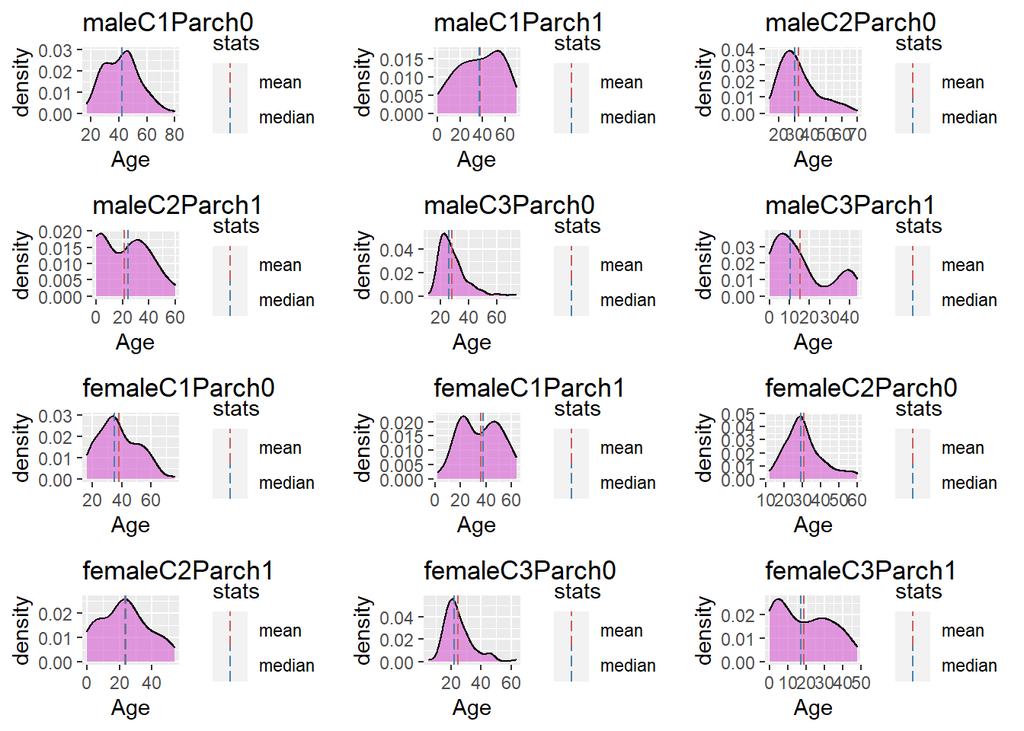

```r
#maleC1Parch0
age_mean1 <- mean(dataset.maleC1Parch0$Age, na.rm = T)
age_median1 <- median(dataset.maleC1Parch0$Age, na.rm = T)

p_maleC1Parch0<-ggplot(dataset.maleC1Parch0, aes(Age)) +
  geom_density(fill = 'orchid', alpha =0.7) +
  geom_vline(aes(xintercept = age_mean1, color = 'mean'), linetype = 5) +
  geom_vline(aes(xintercept = age_median1, color = 'median'), linetype = 5) +
  scale_color_manual(name = "stats", values = c(mean = 'indianred', median = 'steelblue')) +
  ggtitle(label ="maleC1Parch0")

#maleC1Parch1
age_mean2 <- mean(dataset.maleC1Parch1$Age, na.rm = T)
age_median2 <- median(dataset.maleC1Parch1$Age, na.rm = T)

p_maleC1Parch1<-ggplot(dataset.maleC1Parch1, aes(Age)) +
  geom_density(fill = 'orchid', alpha =0.7) +
  geom_vline(aes(xintercept = age_mean2, color = 'mean'), linetype = 5) +
  geom_vline(aes(xintercept = age_median2, color = 'median'), linetype = 5) +
  scale_color_manual(name = "stats", values = c(mean = 'indianred', median = 'steelblue')) +
  ggtitle(label ="maleC1Parch1")

#maleC2Parch0
age_mean3 <- mean(dataset.maleC2Parch0$Age, na.rm = T)
age_median3 <- median(dataset.maleC2Parch0$Age, na.rm = T)

p_maleC2Parch0<-ggplot(dataset.maleC2Parch0, aes(Age)) +
  geom_density(fill = 'orchid', alpha =0.7) +
  geom_vline(aes(xintercept = age_mean3, color = 'mean'), linetype = 5) +
  geom_vline(aes(xintercept = age_median3, color = 'median'), linetype = 5) +
  scale_color_manual(name = "stats", values = c(mean = 'indianred', median = 'steelblue')) +
  ggtitle(label ="maleC2Parch0")

#maleC2Parch1
age_mean4 <- mean(dataset.maleC2Parch1$Age, na.rm = T)
age_median4 <- median(dataset.maleC2Parch1$Age, na.rm = T)

p_maleC2Parch1<-ggplot(dataset.maleC2Parch1, aes(Age)) +
  geom_density(fill = 'orchid', alpha =0.7) +
  geom_vline(aes(xintercept = age_mean4, color = 'mean'), linetype = 5) +
  geom_vline(aes(xintercept = age_median4, color = 'median'), linetype = 5) +
  scale_color_manual(name = "stats", values = c(mean = 'indianred', median = 'steelblue')) +
  ggtitle(label ="maleC2Parch1")

#maleC3Parch0
age_mean5 <- mean(dataset.maleC3Parch0$Age, na.rm = T)
age_median5 <- median(dataset.maleC3Parch0$Age, na.rm = T)

p_maleC3Parch0<-ggplot(dataset.maleC3Parch0, aes(Age)) +
  geom_density(fill = 'orchid', alpha =0.7) +
  geom_vline(aes(xintercept = age_mean5, color = 'mean'), linetype = 5) +
  geom_vline(aes(xintercept = age_median5, color = 'median'), linetype = 5) +
  scale_color_manual(name = "stats", values = c(mean = 'indianred', median = 'steelblue')) +
  ggtitle(label ="maleC3Parch0")

#maleC3Parch1
age_mean6 <- mean(dataset.maleC3Parch1$Age, na.rm = T)
age_median6 <- median(dataset.maleC3Parch1$Age, na.rm = T)

p_maleC3Parch1<-ggplot(dataset.maleC3Parch1, aes(Age)) +
  geom_density(fill = 'orchid', alpha =0.7) +
  geom_vline(aes(xintercept = age_mean6, color = 'mean'), linetype = 5) +
  geom_vline(aes(xintercept = age_median6, color = 'median'), linetype = 5) +
  scale_color_manual(name = "stats", values = c(mean = 'indianred', median = 'steelblue')) +
  ggtitle(label ="maleC3Parch1")

#femaleC1Parch0
age_mean7 <- mean(dataset.femaleC1Parch0$Age, na.rm = T)
age_median7 <- median(dataset.femaleC1Parch0$Age, na.rm = T)

p_femaleC1Parch0<-ggplot(dataset.femaleC1Parch0, aes(Age)) +
  geom_density(fill = 'orchid', alpha =0.7) +
  geom_vline(aes(xintercept = age_mean7, color = 'mean'), linetype = 5) +
  geom_vline(aes(xintercept = age_median7, color = 'median'), linetype = 5) +
  scale_color_manual(name = "stats", values = c(mean = 'indianred', median = 'steelblue')) +
  ggtitle(label ="femaleC1Parch0")

#femaleC1Parch1
age_mean8 <- mean(dataset.femaleC1Parch1$Age, na.rm = T)
age_median8 <- median(dataset.femaleC1Parch1$Age, na.rm = T)

p_femaleC1Parch1<-ggplot(dataset.femaleC1Parch1, aes(Age)) +
  geom_density(fill = 'orchid', alpha =0.7) +
  geom_vline(aes(xintercept = age_mean8, color = 'mean'), linetype = 5) +
  geom_vline(aes(xintercept = age_median8, color = 'median'), linetype = 5) +
  scale_color_manual(name = "stats", values = c(mean = 'indianred', median = 'steelblue')) +
  ggtitle(label ="femaleC1Parch1")

#femaleC2Parch0
age_mean9 <- mean(dataset.femaleC2Parch0$Age, na.rm = T)
age_median9 <- median(dataset.femaleC2Parch0$Age, na.rm = T)

p_femaleC2Parch0<-ggplot(dataset.femaleC2Parch0, aes(Age)) +
  geom_density(fill = 'orchid', alpha =0.7) +
  geom_vline(aes(xintercept = age_mean9, color = 'mean'), linetype = 5) +
  geom_vline(aes(xintercept = age_median9, color = 'median'), linetype = 5) +
  scale_color_manual(name = "stats", values = c(mean = 'indianred', median = 'steelblue')) +
  ggtitle(label ="femaleC2Parch0")

#femaleC2Parch1
age_mean10 <- mean(dataset.femaleC2Parch1$Age, na.rm = T)
age_median10 <- median(dataset.femaleC2Parch1$Age, na.rm = T)

p_femaleC2Parch1<-ggplot(dataset.femaleC2Parch1, aes(Age)) +
  geom_density(fill = 'orchid', alpha =0.7) +
  geom_vline(aes(xintercept = age_mean10, color = 'mean'), linetype = 5) +
  geom_vline(aes(xintercept = age_median10, color = 'median'), linetype = 5) +
  scale_color_manual(name = "stats", values = c(mean = 'indianred', median = 'steelblue')) +
  ggtitle(label ="femaleC2Parch1")

#femaleC3Parch0
age_mean11 <- mean(dataset.femaleC3Parch0$Age, na.rm = T)
age_median11 <- median(dataset.femaleC3Parch0$Age, na.rm = T)

p_femaleC3Parch0<-ggplot(dataset.femaleC3Parch0, aes(Age)) +
  geom_density(fill = 'orchid', alpha =0.7) +
  geom_vline(aes(xintercept = age_mean11, color = 'mean'), linetype = 5) +
  geom_vline(aes(xintercept = age_median11, color = 'median'), linetype = 5) +
  scale_color_manual(name = "stats", values = c(mean = 'indianred', median = 'steelblue')) +
  ggtitle(label ="femaleC3Parch0")

#femaleC3Parch1
age_mean12 <- mean(dataset.femaleC3Parch1$Age, na.rm = T)
age_median12 <- median(dataset.femaleC3Parch1$Age, na.rm = T)

p_femaleC3Parch1<-ggplot(dataset.femaleC3Parch1, aes(Age)) +
  geom_density(fill = 'orchid', alpha =0.7) +
  geom_vline(aes(xintercept = age_mean12, color = 'mean'), linetype = 5) +
  geom_vline(aes(xintercept = age_median12, color = 'median'), linetype = 5) +
  scale_color_manual(name = "stats", values = c(mean = 'indianred', median = 'steelblue')) +
  ggtitle(label ="femaleC3Parch1")


figure_Ages <- ggarrange(p_maleC1Parch0,p_maleC1Parch1,p_maleC2Parch0,p_maleC2Parch1,p_maleC3Parch0,p_maleC3Parch1,p_femaleC1Parch0,p_femaleC1Parch1,p_femaleC2Parch0,p_femaleC2Parch1,p_femaleC3Parch0,p_femaleC3Parch1, ncol = 3, nrow = 4)
figure_Ages
```

```r
impute_age <- function (x) {
    x[is.na(x)] <- median(x, na.rm = T)
    return(x)
}

impute_age(dataset.maleC1Parch0$Age)
```

```
##   [1] 54 28 40 28 42 42 45 42 28 46 71 47 37 24 42 61 56 42 45 40 38 44 62 40 42
##  [26] 42 42 42 45 29 45 42 25 22 28 50 34 52 30 49 65 48 47 56 42 25 58 55 71 18
##  [51] 42 36 47 42 45 50 64 62 42 36 36 49 42 35 27 42 61 80 32 42 48 56 50 47 31
##  [76] 27 31 60 35 42 42 48 27 35 42 36 19 42 29 46 42 39 42 38 42 51 31 33 26 46
## [101] 55 41 30 42 45 24 47 31 28 32 67 49 25 36 53 42 42 42 42 48 54 42 47 42 42
## [126] 39 64 41 27 42 46 24 42 30 57 33 46 39 30 50 49 55 23 17 43
```

```r
dataset.maleC1Parch0$Age<-impute_age(dataset.maleC1Parch0$Age)
dataset.maleC1Parch1$Age<-impute_age(dataset.maleC1Parch1$Age)
dataset.maleC2Parch0$Age<-impute_age(dataset.maleC2Parch0$Age)
dataset.maleC2Parch1$Age<-impute_age(dataset.maleC2Parch1$Age)
dataset.maleC3Parch0$Age<-impute_age(dataset.maleC3Parch0$Age)
dataset.maleC3Parch1$Age<-impute_age(dataset.maleC3Parch1$Age)
dataset.femaleC1Parch0$Age<-impute_age(dataset.femaleC1Parch0$Age)
dataset.femaleC1Parch1$Age<-impute_age(dataset.femaleC1Parch1$Age)
dataset.femaleC2Parch0$Age<-impute_age(dataset.femaleC2Parch0$Age)
dataset.femaleC2Parch1$Age<-impute_age(dataset.femaleC2Parch1$Age)
dataset.femaleC3Parch0$Age<-impute_age(dataset.femaleC3Parch0$Age)
dataset.femaleC3Parch1$Age<-impute_age(dataset.femaleC3Parch1$Age)

dataset_imputed<-rbind(dataset.maleC1Parch0,dataset.maleC1Parch1,dataset.maleC2Parch0,dataset.maleC2Parch1,dataset.maleC3Parch0,dataset.maleC3Parch1,dataset.femaleC1Parch0,dataset.femaleC1Parch1,dataset.femaleC2Parch0,dataset.femaleC2Parch1,dataset.femaleC3Parch0,dataset.femaleC3Parch1)

dataset_imputed<-dataset_imputed[,c('PassengerId','Age')]
names(dataset_imputed)[2]<-'Age_imp'

dataset<-merge(dataset,dataset_imputed,by = 'PassengerId')
```

## 3.2 Creació de variables

### 3.2.1 Creació variable ‘Title’

A partir del nom dels passatgers es poden extreure els titols d’algun d’ells.

```r
# Extreiem el 'titol' de cada passatger. Com que el format dels nomes sempre es el mateix podem seguir una estructura per trobar-los
dataset$title <- str_sub(dataset$Name, str_locate(dataset$Name, ",")[ , 1] + 2, str_locate(dataset$Name, "\\.")[ , 1] - 1)

# combines els títols dels passatgers en grups segons si considerem que formen part de la noblesa (i.e. tenen algun títol, o no)
# Titols nobles per homes
names_noblesa <- c("Capt", "Col", "Don", "Dr", "Jonkheer", "Major", "Rev", "Sir","Lady", "Mlle", "Mme", "Ms", "the Countess", "Dona")
dataset$title[dataset$title %in% names_noblesa] <- "noble"
dataset$title<-factor(dataset$title)
# Comprobem el resultat final
table(dataset$title)
```

```
##
## Master   Miss     Mr    Mrs  noble
##     61    260    757    197     34
```

### 3.2.2 Creació variable ‘Zona’

De la variable ‘cabin’ extreiem la lletra que segurament representa la zona del vaixell on es troba la cabina.

```r
Zona <- dataset %>%
  select(Cabin) %>%
  mutate(Zona = factor(str_extract(Cabin, pattern = "^.")))

dataset$Zona<-as.character(Zona$Zona)

for (i in 1:length(dataset$Zona)){
  if(is.na(dataset[i,]$Zona)){
    dataset[i,]$Zona<-'Desconeguda'
  }
}

dataset$Zona<-factor(dataset$Zona)
```

### 3.2.3 Creació variable ‘Familiy_Size’ i ‘FamilyCat’

El tamany de les families es pot inferir a partir de les variables ‘SibSp’ i ‘Parch’. A més, tota aquella gent que comparteixi cognom és probable que formin part de la mateixa familia. Dataset d’entrenament:

```r
#Creem la variable 'Familiy_name"
dataset$Family_name <- str_replace(string = dataset$Name, pattern = ",.*", replacement = "")

#Visualitzem les dades
dataset %>%
  select(Name, Family_name) %>%
  head(10)
```

```
##                                                   Name Family_name
## 1                              Braund, Mr. Owen Harris      Braund
## 2  Cumings, Mrs. John Bradley (Florence Briggs Thayer)     Cumings
## 3                               Heikkinen, Miss. Laina   Heikkinen
## 4         Futrelle, Mrs. Jacques Heath (Lily May Peel)    Futrelle
## 5                             Allen, Mr. William Henry       Allen
## 6                                     Moran, Mr. James       Moran
## 7                              McCarthy, Mr. Timothy J    McCarthy
## 8                       Palsson, Master. Gosta Leonard     Palsson
## 9    Johnson, Mrs. Oscar W (Elisabeth Vilhelmina Berg)     Johnson
## 10                 Nasser, Mrs. Nicholas (Adele Achem)      Nasser
```

```r
#Ceem la variable 'Family_size' (sumem 1 per assegurar-nos de que el passatger també es té en compte en la seva propia familia)
dataset <- dataset %>%
  mutate(Family_size = SibSp + Parch + 1)

#Visualitzem les dades
dataset %>%
  select(Family_name, SibSp, Parch, Family_size) %>%
   arrange(Family_name)%>%
  head(10)
```

```
##    Family_name SibSp Parch Family_size
## 1       Abbing     0     0           1
## 2       Abbott     1     1           3
## 3       Abbott     1     1           3
## 4       Abbott     0     2           3
## 5     Abelseth     0     0           1
## 6     Abelseth     0     0           1
## 7      Abelson     1     0           2
## 8      Abelson     1     0           2
## 9  Abrahamsson     0     0           1
## 10     Abrahim     0     0           1
```

Categorizem el tamany de les families segons si el passatger va sol, en familia/grup gran o petit

```r
dataset <- dataset %>%
  mutate(FamilyCat = factor(case_when(Family_size == 1 ~ 'sol'
                            ,Family_size > 1 & Family_size < 5 ~ 'petita'
                            ,Family_size >= 5 & Family_size < 7 ~ 'moderada'
                            ,Family_size >= 7 ~ 'gran')))
```

### 3.2.4 Creació variable ‘Price_Person’

```r
dataset$Price_Per_Person<-dataset$Fare/dataset$Family_size
```

Podem visualitzar com ara el preu pagat per ticket per a cada passatger, es mou dins d’un rang logic segons la classe en la que viatjaven: 1a classe = >18 dolars, 2a class = 9-18 dollars, 3a classe = < 9 dolars.

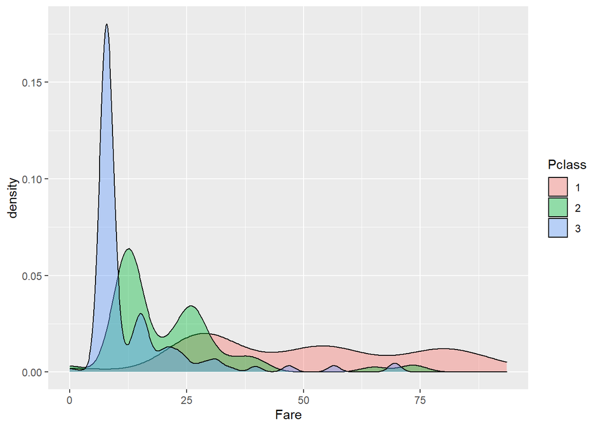

```r
# Use semi-transparent fill
p_fare<-ggplot(dataset[which(dataset$Fare<100),], aes(x=Fare, fill=Pclass)) +
  geom_density(alpha=0.4)
p_fare
```

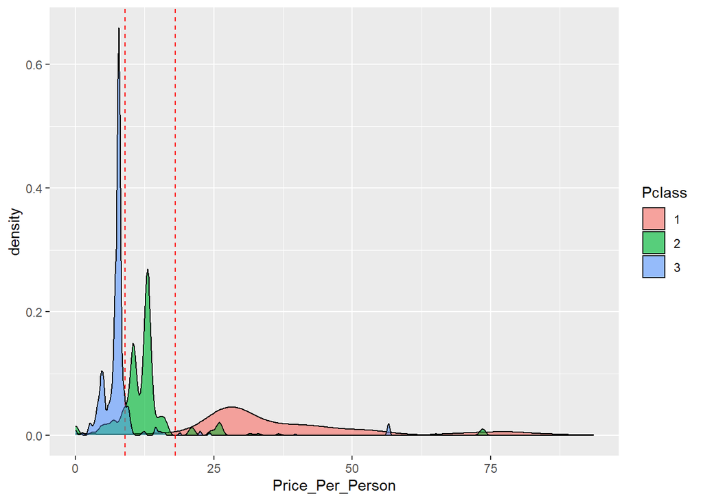

```r
# Use semi-transparent fill
p_priceperson<-ggplot(dataset[which(dataset$Price_Per_Person<100),], aes(x=Price_Per_Person, fill=Pclass)) +
  geom_density(alpha=0.4)+ geom_vline(xintercept = 9, linetype="dashed",
                color = "red", size=0.5) +
  geom_density(alpha=0.4)+ geom_vline(xintercept = 18, linetype="dashed",
                color = "red", size=0.5)
p_priceperson
```

```r
has_na(dataset)
```

```
## [1] "La variable  Age  té  263  valors nul"
## [1] "La variable  Cabin  té  1014  valors buits"
```

```r
table(dataset$Embarked,useNA='always')
```

```
##
##    C    Q    S <NA>
##  270  123  916    0
```

### 3.2.5 Creació variable ‘AgeCat’

Observem quin és el rang de valors que pren la variable *Age*:

```r
summary(dataset$Age_imp)
```

```
##    Min. 1st Qu.  Median    Mean 3rd Qu.    Max.
##    0.00   22.00   26.00   29.15   36.00   80.00
```

```r
dataset["AgeCat"] <- cut(dataset$Age_imp, breaks = c(-1,10,18,55,100), labels = c("nens","adolescents","adults","ancians"))

table(dataset$AgeCat,useNA='always')
```

```
##
##        nens adolescents      adults     ancians        <NA>
##          86         138        1027          58           0
```

### 3.2.6 Creació variable ‘PriceCat’

Com hem vist abans, la distribució del preu per persona (Price_Per_Person) segons classe en la que viatgen els passatgers sembla indicar que tenim un preu de referencia del tiquet segons la classe en la que es viatges. Així doncs, hem decidit discretitzar la variable Price_Per_Person en tres grups: preu baix, mig i alt.

```r
summary(dataset$Price_Per_Person)
```

```
##    Min. 1st Qu.  Median    Mean 3rd Qu.    Max.
##   0.000   7.453   8.567  20.509  24.150 512.329
```

```r
dataset["PriceCat"] <- cut(dataset$Price_Per_Person, breaks = c(-1,9,18,513), labels = c("baix","mig","alt"))
```

## 3.3 Gestió de valors extrems (outliers)

Els outliers són valors extrems que es trobem molt lluny de la distribució normal o esperada d’un atribut. De forma formal es solen definir com aquells valors que es troben a més de 3 desviacions estàndards de la mitjana, tot i que altres consideren definicions més estrictes com més enllà de 6 desviacions estàndards de la mitjana. Aquests poden incrementar l’error en la variància i conseqüentment reduir el poder estadístic d’un test alhora de fer estimacions significatives, o que aquestes estimacions estiguin esbiaixades. A més, la presència d’aquests pot afectar dràsticament a la mitjana.

Així doncs, cal observar els valors extrems de les variables numèriques i considerar si es corresponen a valors errònis que cal evitar o bé són casos extrems que convé mantenir.

Per començar l’anàlisi de valors atípics hem creat una funció que mostra els diagrames de caixa de les diferents variables numèriques:

```r
mostrar_diag_caixa <- function(dades, variables_numeriques) {
  mida <- ceiling(sqrt(length(variables_numeriques)))
  par(mfrow=c(2,2))
  for (i in variables_numeriques) {
    boxplot(dades[[i]], main=i, horizontal = TRUE)
  }
}
```

I una altra que indica textualment els valors atípics d’una variable:

```r
deteccio_valors_atipics <- function(dades,variables_numeriques) {
  for (i in variables_numeriques) {
    valors_atipics <- boxplot.stats(dades[[i]])$out
    if (length(valors_atipics != 0)) {
      print(paste("La variable", i, "té els valors atípics: "))
      print(valors_atipics)
    }
  }
}
```

Un cop creades les funcions, les cridem passant-los hi les dades de cada fitxer i un vector amb el nom de les variables numèriques que contenen:

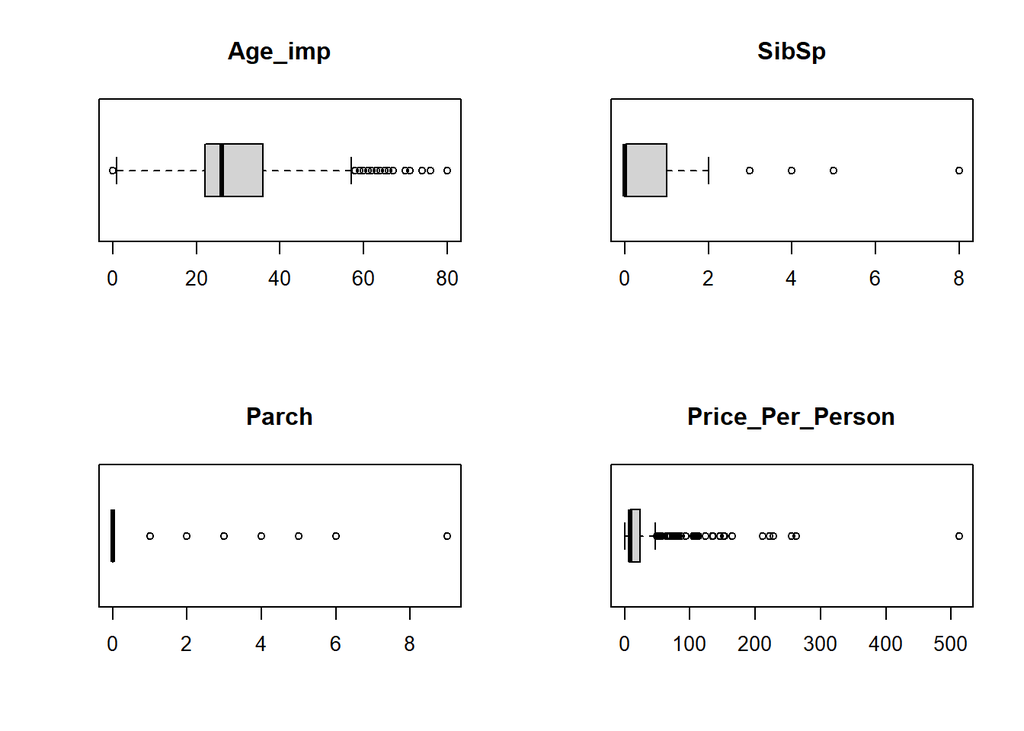

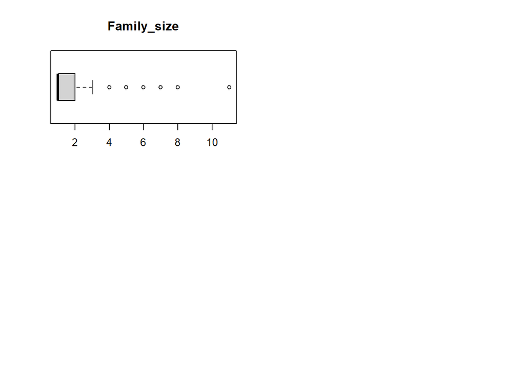

```r
mostrar_diag_caixa(dataset,c("Age_imp","SibSp","Parch","Price_Per_Person","Family_size"))
```

Com hem vist enteriorment, tenim varies variables a considerar: Age_imp (omitim Age), SibSp, Parch, Family_size i Price_Per_Person (ommitim Fare).

Tot i que tenim varis valors que s’allunyen considerablement de la mitjana de la distribució d’aquestes variables, considerem que els valors extrems observats són llògics i esperables ja que es moun dins d’un rang de valors que esperariem, tant pel que fa a les edats, o al número de familiars a bord o tamany de familia. L’única variable que ens faria dubtar és el preu pagat per tiquet, tot i que ens falta informació per a saber si aquests preus extrems serien possible (e.g. tiquet a 1a classe comprat a última hora en la millor cabina). Tot i així, com que treballarem amb la variable PriceCat, i tots aquests valors queden categoritzats dins de la categoria de preu ‘alt’, no és rellevant i per tant no eliminem cap d’aquests valors extrems.

Així doncs considerem que no hi ha outliers a eliminar en les nostres dades finals.

```r
deteccio_valors_atipics(dataset,c("Age_imp","SibSp","Parch","Price_Per_Person","Family_size"))
```

```
## [1] "La variable Age_imp té els valors atípics: "
##  [1] 58 66 65  0 59 71 70 61 58 59 62 58 63 65  0 61 60 64 65  0 63 58 71 64 62
## [26] 62 60 61 80  0 58 70 60 60 70  0  0 62  0 74 62 63 60 60 67 76 63 61 60 64
## [51] 61  0 60 64  0  0 64  0 58  0 59
## [1] "La variable SibSp té els valors atípics: "
##  [1] 3 4 3 3 4 5 3 4 5 3 3 4 8 4 4 3 8 4 8 3 4 4 4 4 8 3 3 5 3 5 3 4 4 3 3 5 4 3
## [39] 4 8 4 3 4 8 4 8 3 4 5 3 4 8 4 8 4 3 3
## [1] "La variable Parch té els valors atípics: "
##   [1] 1 2 1 5 1 1 5 2 2 1 1 2 2 2 1 2 2 2 3 2 2 1 1 1 1 2 1 1 2 2 1 2 2 2 1 2 1
##  [38] 1 2 1 4 1 1 1 1 2 2 1 2 1 1 1 2 1 1 2 2 2 1 1 2 2 1 2 1 1 1 1 1 1 1 2 1 2
##  [75] 2 1 1 2 1 1 2 1 1 1 1 2 1 1 1 4 1 1 2 2 2 2 2 1 1 1 2 2 1 1 2 2 3 4 1 2 1
## [112] 1 2 1 2 1 2 1 1 2 2 1 1 1 1 2 2 2 2 2 2 1 1 2 1 4 1 1 2 1 2 1 1 2 5 2 1 1
## [149] 1 2 1 5 2 1 1 1 2 1 6 1 2 1 2 1 1 1 1 1 1 1 3 2 1 1 1 1 2 1 2 3 1 2 1 2 2
## [186] 1 1 2 1 2 1 2 1 1 1 2 1 1 2 1 2 1 1 1 1 3 2 1 1 1 1 5 2 1 1 1 1 3 1 2 2 1
## [223] 2 1 2 1 2 4 1 1 2 1 1 1 4 6 2 3 1 1 2 2 2 1 1 2 5 2 3 2 1 1 1 2 1 2 2 2 1
```

[output cut: 25 more lines]